# LCMS analysis

Eric R. Scott

2019-07-26

*Last compiled: 2019-09-22*

```r
#Custom tidier for chngpt models. Turns output into dataframe.  Warning: this is not very reusable code.
tidy.chngpt <- function(chngpt.mod) {
  df <- bind_cols(
    chngpt.mod$coefficients[1:2] %>% t() %>% as_tibble(),
    summary(chngpt.mod)$chngpt %>%  set_names(c("chngpt", "chngpt.lower.CI", "chngpt.upper.CI")) %>% t() %>% as_tibble()
  )
  return(df)
}
```

# 1 Purpose

Analysis of LCMS data from 2017 and 2018 leafhopper density experiments.

# 2 Load Data

```r
lc2017 <- read_rds(here("data", "cleaned", "2017_lcms_wide.rds")) %>%
  filter(sample != "Q2") #determined elsewhere that this has an unusually high ammount of damage for the treatment

lc2018 <- read_rds(here("data", "cleaned", "2018_lcms_wide.rds")) %>%
  filter(sample != "J23") #determined elswhere that this has an unusually high ammount of damage for the treatment

lc2017_tidy <-
  read_rds(here('data', 'cleaned', '2017_lcms_tidy.rds')) %>%
  filter(sample != "Q2")

lc2018_tidy <-
  read_rds(here('data', 'cleaned', '2018_lcms_tidy.rds')) %>%
  filter(sample != "J23")
```

## 2.1 Data Dictionary

`lc2017` and `lc2018`: Wide versions of LCMS data for both years with compounds as columns.

- `sample`: sample name
- `cultivar`: Q = Qing Xin Da Mao, L = Long Jing, J = Jin Guan Yin
- `plant_num`: another identifier, extracted from sample name
- `mean_leaf_area_px`: mean leaf area in pixels
- `mean_percent_damage`: mean percent area damaged
- `n_leaves`: number of leaves scanned and ground into powder for this analysis
- `twister_damage`: percent damage on the twister leaf. Ignore for LCMS analysis.
- `density_treatmetn`: categorical. This was the leafhopper density I aimed to treat the plants with in insects/young leaf for 2017 and insects/shoot in 2018
- `density_start`, `density_end`: The density of leafhoppers at the start and end of the experiments. In insects/young leaf in 2017 and insects/shoot in 2018
- The rest of the columns are concentrations of compounds in **µg/mg** leaf

# 3 Analysis

## 3.1 Deal with NAs

NAs are non-detects. I should replace them with 0 or a very small number.

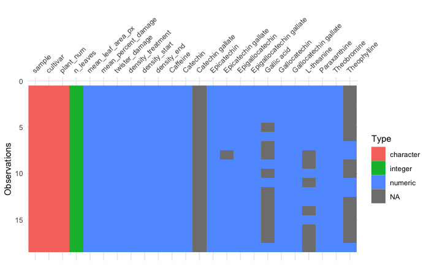

```r
vis_dat(lc2017)
```

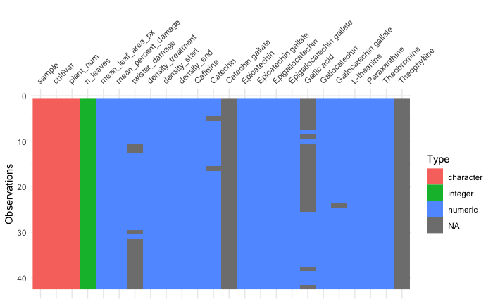

```r
vis_dat(lc2018)
```

```r
# min(lc2017_tidy$conc_ug_mg, na.rm = TRUE)

lc2017_tidy <-
  lc2017_tidy %>%
  filter(!compound %in% c("Catechin gallate", "Theophylline")) %>% #not detected in any sample
  mutate(conc_ug_mg = ifelse(is.na(conc_ug_mg), 0.0001, conc_ug_mg))

lc2017_2 <-
  lc2017 %>%
  mutate_all(~ifelse(is.na(.), 0.0001, .)) %>%
  select(-`Catechin gallate`, -`Theophylline`) #all zeroes

# min(lc2018_tidy$conc_ug_mg, na.rm = TRUE)
lc2018_tidy <-
  lc2018_tidy %>%
  filter(!compound %in% c("Catechin gallate", "Theophylline")) %>% #all zeros for all samples
  mutate(conc_ug_mg = ifelse(is.na(conc_ug_mg), 0.0001, conc_ug_mg))

lc2018_2 <-
  lc2018 %>%
  mutate_all(~ifelse(is.na(.), 0.0001, .)) %>%
  select(-`Catechin gallate`, -Theophylline) #all zeroes
```

## 3.2 Scale and transform data

```r
lc2017_scaled <-
  lc2017_2 %>%
  mutate_at(vars(Caffeine:Theobromine), scale) %>%
  mutate(log_damage = log(mean_percent_damage))

lc2017_tidy <-
  lc2017_tidy %>%
  mutate(log_damage = log(mean_percent_damage))

lc2018_2 <-
  lc2018_2 %>%
  mutate(log_damage = log(mean_percent_damage))

lc2018_tidy <-
  lc2018_tidy %>%
  mutate(log_damage = log(mean_percent_damage))
```

## 3.3 Examine correlations

```
Correlation method: 'pearson'
Missing treated using: 'pairwise.complete.obs'
```

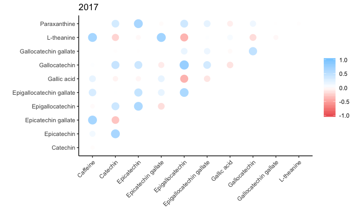

```r
corrr::correlate(lc2017_2[11:21]) %>%
  corrr::shave() %>%
  corrr::rplot() +
  theme(axis.text.x = element_text(angle = 45, hjust = 1)) +
  labs(title = "2017")
```

```
Correlation method: 'pearson'
Missing treated using: 'pairwise.complete.obs'
```

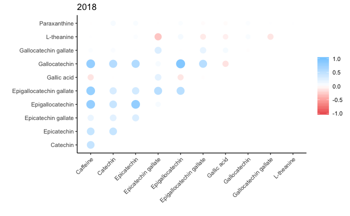

```r
corrr::correlate(lc2018_2[11:21]) %>%
  corrr::shave() %>%
  corrr::rplot() +
  theme(axis.text.x = element_text(angle = 45, hjust = 1)) +
  labs(title = "2018")
```

There are some strong correlations, so multivariable methods are best.

# 4 2017

## 4.1 Leafhopper density RDA

1. Fit RDA model

```r
dens_rda.2017 <-
  rda(lc2017_scaled %>% select(Caffeine:Theobromine) ~ density_end, data = lc2017_scaled)
```

2. How much total variance does the experimental design explain?

```r
MVA.synt(dens_rda.2017)[[1]][[2]]
```

|  | Proportion | Cumulative |
| --- | --- | --- |
| Constrained | 5.447767 | 5.447767 |
| Unconstrained | 94.552233 | 100.000000 |

Only 5.45% variation explained

3. Test for significance that this amount of explained variance is higher than the null hypothesis of no effect of the experimental design:

```r
anova(dens_rda.2017)
```

```
Permutation test for rda under reduced model
Permutation: free
Number of permutations: 999

Model: rda(formula = lc2017_scaled %>% select(Caffeine:Theobromine) ~ density_end, data = lc2017_scaled)
         Df Variance      F Pr(>F)
Model     1   0.6537 0.9219  0.458
Residual 16  11.3463
```

## 4.2 Mean leaf damage RDA

1. fit model

```r
dam_rda.2017 <-
  rda(lc2017_scaled %>% select(Caffeine:Theobromine) ~ log_damage, data = lc2017_scaled)
```

2. How much total variance does the experimental design explain?

```r
MVA.synt(dam_rda.2017)[[1]][[2]]
```

|  | Proportion | Cumulative |
| --- | --- | --- |
| Constrained | 9.583927 | 9.583927 |
| Unconstrained | 90.416073 | 100.000000 |

9.58 % of variation explained

3. Test for significance that this amount of explained variance is higher than the null hypothesis of no effect of the experimental design:

```r
anova(dam_rda.2017)
```

```
Permutation test for rda under reduced model
Permutation: free
Number of permutations: 999

Model: rda(formula = lc2017_scaled %>% select(Caffeine:Theobromine) ~ log_damage, data = lc2017_scaled)
         Df Variance     F Pr(>F)
Model     1   1.1501 1.696  0.114
Residual 16  10.8499
```

### 4.2.1 Get biomarkers for damage

```r
scores <- MVA.scores(dam_rda.2017)$coord
loads <- MVA.load(dam_rda.2017)$loads %>% rename(loading = `Constr. comp. 1`)
```

```
wrong 'yax', only 'xax' used
```

```r
data <- lc2017_scaled %>% select(Caffeine:Theobromine)

lc_biomarkers_2017 <-
  map_df(data, ~cor.test(.x, scores[["Constr. comp. 1"]]) %>% broom::glance(), .id = "compound") %>%
  bind_cols(loads) %>%
  filter(p.value <= 0.05) %>%
  select(compound, loading, correlation = estimate, p.value) %>%
  arrange(desc(abs(correlation)))
lc_biomarkers_2017
```

| compound | loading | correlation | p.value |
| --- | --- | --- | --- |
| Epigallocatechin gallate | -0.5691773 | -0.8303520 | 0.00001996105 |
| Theobromine | -0.3935291 | -0.7659153 | 0.00021083130 |
| Caffeine | -0.2801435 | -0.7329816 | 0.00053921426 |
| Epicatechin gallate | -0.3495588 | -0.6513361 | 0.00340992765 |

Univariate measures

Fit null, linear, step, and hinge models to all four compounds.

| compound | data | type | model | fit | AIC | (Intercept) | I(log_damage>chngpt) | chngpt | chngpt.lower.CI | chngpt.upper.CI | (log_damage-chngpt)+ |
| --- | --- | --- | --- | --- | --- | --- | --- | --- | --- | --- | --- |
| Caffeine |  | linear |  |  | 122.580745 | NA | NA | NA | NA | NA | NA |
| Caffeine |  | null |  |  | 122.283442 | NA | NA | NA | NA | NA | NA |
| Caffeine |  | step |  |  | Inf | 17.4277949 | -8.2800697 | 1.6576018 | -0.0489989 | 3.364203 | NA |
| Caffeine |  | hinge |  |  | Inf | 17.1628897 | NA | 1.6268650 | -0.0489989 | 3.302729 | -16.7539780 |
| Epicatechin gallate |  | linear |  |  | 99.122724 | NA | NA | NA | NA | NA | NA |
| Epicatechin gallate |  | null |  |  | 99.848606 | NA | NA | NA | NA | NA | NA |
| Epicatechin gallate |  | step |  |  | 96.353312 | 11.3865742 | -3.6486915 | 0.8515277 | -0.0489989 | 1.752054 | NA |
| Epicatechin gallate |  | hinge |  |  | Inf | 11.2180819 | NA | 0.4526321 | -0.7216008 | 1.626865 | -2.5741733 |
| Epigallocatechin gallate |  | linear |  |  | 123.396532 | NA | NA | NA | NA | NA | NA |
| Epigallocatechin gallate |  | null |  |  | 129.787043 | NA | NA | NA | NA | NA | NA |

[output cut: 6 more lines]

Choose best fit manually by AIC:

- Caffeine: null
- Epicatechin gallate: step is best fit, but not significant, so null
- Epigallocatechin gallate: linear
- Theobromine: step is best fit, but not significant, same with hinge, linear is marginally significant

Check that changepoint doesn’t overlap zero

```r
lc_lm_2017 <-
  lc_lm_2017 %>%
  ungroup() %>%
  filter(compound == "Caffeine" & type == "null" |
           compound == "Epicatechin gallate" & type == "null" |
           compound == "Epigallocatechin gallate" & type == "linear" |
           compound == "Theobromine" & type == "linear")
```

```r
lc_biomarkers_2017 <- full_join(lc_biomarkers_2017, lc_lm_2017)
```

## 4.3 Plots

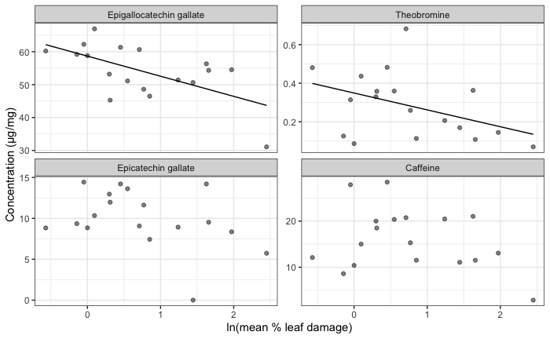

```r
lc_plotdata.2017 <-
  left_join(lc_biomarkers_2017, lc2017_tidy) %>%
  mutate(compound = fct_reorder(compound, abs(loading), .desc = TRUE))
lc_plot.2017 <-
  ggplot(lc_plotdata.2017, aes(x = log_damage, y = conc_ug_mg)) +
  geom_point(alpha = 0.5) +
  geom_smooth(method = "lm",
              se = FALSE,
              data = lc_plotdata.2017 %>%
                filter(compound %in% c("Epigallocatechin gallate", "Theobromine")),
              color = "black", size = 0.5, linetype = 1) +
  #  #step
  # geom_segment(aes(x = min(log_damage),
  #                xend = chngpt,
  #                y = `(Intercept)`,
  #                yend = `(Intercept)`), color = "black") +
  # geom_segment(aes(x = chngpt,
  #                  xend = max(log_damage),
  #                  y = `(Intercept)`+`I(log_damage>chngpt)`,
  #                  yend = `(Intercept)`+`I(log_damage>chngpt)`), color = "black") +
  facet_wrap(~compound, scales = "free_y") +
  theme_bw() +
  labs(x = "ln(mean % leaf damage)",
       y = "Concentration (µg/mg)")
lc_plot.2017
```

```r
save_plot(here("figs", "lc_biomarker_plot_2017.png"), lc_plot.2017,
          ncol = 2,
          nrow = 2,
          base_height = 2,
          base_asp = 1.3)
```

# 5 2018

## 5.1 Checking effect of processing time

In this year, I was unable to keep samples refridgerated as I processed them (scanning, then microwaving, then drying). Scanning was the bottleneck step, so the first samples spent a lot less time sitting out on the counter after being harvested than the last samples. To check for an effect of sample order, I pulled the file creation times from all the scanned images and merged them with the data. Then, I used the time the scan was created as a conditional variable in an RDA. It only explained about 1% of the variation in the LCMS compounds, so I won’t use it as a covariate going forward.

```r
jgy_path <- "/Volumes/as_rsch_orianslab_tea01$/Image Analysis/2018/Leaf Scans/Manipulative/Jin Guan Yin"
lj_path <- "/Volumes/as_rsch_orianslab_tea01$/Image Analysis/2018/Leaf Scans/Manipulative/Longjing"

jgy_info <-
  dir(jgy_path, "*.jpg", full.names = TRUE) %>%
  file.info() %>%
  as_tibble(rownames = "paths") %>%
  mutate(plant_num = str_extract(paths, "\\d+(?=\\w?\\.jpg$)")) %>%
  mutate(sample = paste0("J", plant_num)) %>%
  mutate(mtime = if_else(sample == "J18",
                         ymd_hms("2018-07-30 23:17:00") + hours(4),
                         mtime)) %>%
  mutate(time = mtime - min(mtime))

lj_info <-
  dir(lj_path, "*.png", full.names = TRUE) %>%
  file.info() %>%
  as_tibble(rownames = "paths") %>%
  mutate(plant_num = str_extract(paths, "\\d+(?=\\w?\\.png$)")) %>%
  mutate(sample = paste0("L", plant_num)) %>%
  mutate(time = mtime - min(mtime))

processing_time <-
  bind_rows(jgy_info, lj_info) %>%
  select(sample, plant_num, time) %>%
  group_by(sample) %>%
  summarize(time = min(time))
```

```r
lc2018_scaled <-
  lc2018_2 %>%
  mutate_at(vars(Caffeine:Theobromine), scale) %>%
  mutate(cultivar = as.factor(cultivar)) %>%
  left_join(processing_time)

rda.2018 <-
  rda(lc2018_scaled %>% select(Caffeine:Theobromine) ~ log_damage*cultivar + Condition(as.numeric(time)),
      data = lc2018_scaled)
```

```r
MVA.synt(rda.2018)
```

[output not shown]

## 5.2 Split cultivars

It doesn’t make sense to include both cultivars in the analysis.

```r
lc_jgy <-
  lc2018_2 %>%
  filter(cultivar == "J") %>%
  mutate_at(vars(Caffeine:Theobromine), scale)
lc_lj <-
  lc2018_2 %>%
  filter(cultivar == "L") %>%
  mutate_at(vars(Caffeine:Theobromine), scale)
```

## 5.3 Jin Guan Yin

1. Fit RDA models

```r
rda_dens_jgy <-
  rda(lc_jgy %>% select(Caffeine:Theobromine) ~ density_end,
      data = lc_jgy)

rda_dam_jgy <-
  rda(lc_jgy %>% select(Caffeine:Theobromine) ~ log_damage,
      data = lc_jgy)
```

2. How much total variance does the experimental design explain?

```r
MVA.synt(rda_dens_jgy)[[1]][[2]]
```

|  | Proportion | Cumulative |
| --- | --- | --- |
| Constrained | 2.709244 | 2.709244 |
| Unconstrained | 97.290756 | 100.000000 |

```r
MVA.synt(rda_dam_jgy)[[1]][[2]]
```

|  | Proportion | Cumulative |
| --- | --- | --- |
| Constrained | 2.547984 | 2.547984 |
| Unconstrained | 97.452016 | 100.000000 |

Very small numbers here.

3. Test for significance that this amount of explained variance is higher than the null hypothesis of no effect of the experimental design:

```r
anova(rda_dens_jgy)
```

```
Permutation test for rda under reduced model
Permutation: free
Number of permutations: 999

Model: rda(formula = lc_jgy %>% select(Caffeine:Theobromine) ~ density_end, data = lc_jgy)
         Df Variance      F Pr(>F)
Model     1   0.3251 0.5848  0.723
Residual 21  11.6749
```

```r
anova(rda_dam_jgy)
```

```
Permutation test for rda under reduced model
Permutation: free
Number of permutations: 999

Model: rda(formula = lc_jgy %>% select(Caffeine:Theobromine) ~ log_damage, data = lc_jgy)
         Df Variance      F Pr(>F)
Model     1   0.3058 0.5491  0.747
Residual 21  11.6942
```

Definitely not significant

## 5.4 Long Jing

1. Fit RDA model

```r
rda_dens_lj <-
  rda(lc_lj %>% select(Caffeine:Theobromine) ~ density_end,
      data = lc_lj)

rda_dam_lj <-
  rda(lc_lj %>% select(Caffeine:Theobromine) ~ log_damage,
      data = lc_lj)
```

2. How much total variance does the experimental design explain?

```r
MVA.synt(rda_dens_lj)[[1]][[2]]
```

|  | Proportion | Cumulative |
| --- | --- | --- |
| Constrained | 6.893147 | 6.893147 |
| Unconstrained | 93.106853 | 100.000000 |

```r
MVA.synt(rda_dam_lj)[[1]][[2]]
```

|  | Proportion | Cumulative |
| --- | --- | --- |
| Constrained | 6.208151 | 6.208151 |
| Unconstrained | 93.791849 | 100.000000 |

~ 6-7% for both

3. Test for significance that this amount of explained variance is higher than the null hypothesis of no effect of the experimental design:

```r
anova(rda_dens_lj)
```

```
Permutation test for rda under reduced model
Permutation: free
Number of permutations: 999

Model: rda(formula = lc_lj %>% select(Caffeine:Theobromine) ~ density_end, data = lc_lj)
         Df Variance      F Pr(>F)
Model     1   0.8272 1.2586  0.287
Residual 17  11.1728
```

```r
anova(rda_dam_lj)
```

```
Permutation test for rda under reduced model
Permutation: free
Number of permutations: 999

Model: rda(formula = lc_lj %>% select(Caffeine:Theobromine) ~ log_damage, data = lc_lj)
         Df Variance      F Pr(>F)
Model     1    0.745 1.1252  0.313
Residual 17   11.255
```

not significant